# Analisis EPH

#### Librerías necesarias

```r
library(quantreg);
library(eph);
library(dplyr);
library(tidyr);
library(ggplot2);
source("scripts/utils.R");
library(dineq);
library(ineq);
library(knitr);
library(oaxaca);
```

Toda función auxiliar que uso a lo largo del trabajo está en `utils.R`. Para detalles de implementación y decisiones, ir al archivo.

#### **Lectura de datos**

```r
resultados <- datos(2023,4)

bases23 <- resultados$bases
bases23_rest <- resultados$bases_rest
hogares23 <- resultados$hogares

resultados <- datos(2024,2)

bases24 <- resultados$bases
bases24_rest <- resultados$bases_rest
hogares24 <- resultados$hogares

rm(resultados) # eliminamos la variable resultados
```

- bases**N**: lista que contiene las bases de microdatos `individuales` correspondientes al año 20**N** (los 4 trimestres).
- bases**N**_rest: lista análoga a la anterior, pero habiendo hecho una limpieza de los datos.
- hogares**N**: lista que contiene las bases de microdatos de `hogares` correspondientes al año 20**N**.

Notar que, al día de la fecha, aún no están disponibles los datos del 3er y 4to trimestre del 2024. Por ello no se tuvo en cuenta, pero haciendo un ligero cambio en `utils.R` se pueden agregar al análisis.

#### **Datos, Preprocesamiento y decisiones tomadas**

Fuente: bases de datos de la Encuesta Permanente de Hogares (EPH).

- **Nombres representativos:**  
  Renombramos las variables para hacerlas más claras y representativas en el contexto del análisis.
- **Eliminación de datos inconsistentes:**  
  Filtramos observaciones con valores lógicamente imposibles o inconsistentes. Por ejemplo:
  - Individuos que reportaron trabajar más de 168 horas semanales (el máximo teórico en una semana).
  - Otras inconsistencias identificadas en las variables clave del análisis.
- **Manejo de datos faltantes:**  
  En este estudio, decidí no realizar imputaciones para los valores faltantes y, en cambio, eliminé las filas afectadas. Esta decisión se basó en las siguientes consideraciones:
  - **Evitar suposiciones fuertes:**  
    La imputación requiere hacer suposiciones sobre cómo se distribuyen los datos faltantes o su relación con otras variables. En este caso, los valores faltantes podrían estar asociados a fenómenos específicos, como licencias remuneradas, contratos especiales o errores de reporte, y no podemos garantizar que las imputaciones reflejaban con precisión estas situaciones.
  - **Minimizar el sesgo potencial:**  
    La imputación podría alterar las relaciones entre las variables explicativas y la variable dependiente, afectando la validez de los coeficientes estimados. Al eliminar estas observaciones, los resultados reflejan únicamente los datos observados.
  - **Transparencia y replicabilidad:**  
    Prioricé un enfoque transparente eliminando las filas con valores faltantes, manteniendo una muestra final suficientemente grande ($n = 18,011$) para garantizar la representatividad del análisis.
  - **Consistencia con la literatura:**  
    En estudios econométricos similares, es común eliminar observaciones con valores faltantes cuando no se pueden realizar imputaciones con un nivel razonable de certeza. Esta práctica está alineada con estándares aceptados en el campo.
- **Cálculo de años de educación ($\text{anios_edu}$):**  
  Estimamos los años de educación en función de las variables relacionadas con el nivel educativo, el año aprobado y si el nivel fue completado (ver `utis.R`, líneas 14-28).
- **Estimación de experiencia potencial ($\text{exp_pot}$):**  
  Calculamos la experiencia potencial siguiendo la fórmula:

  $$\text{exp_pot} = \text{edad} -
  \text{anios_edu} - 6$$
- **Filtrado de filas por edad:**  
  Seleccionamos únicamente observaciones correspondientes a personas entre 25 y 65 años.
  - Este rango de edad refleja mejor la población laboral estable y con trayectorias educativas y laborales completas. Incluir a menores de 25 años podría introducir ruido en los datos debido a educación incompleta o trabajos transitorios, mientras que mayores de 65 años suelen estar en transición hacia la jubilación.
- **Horas mensuales:**
  - En los datos se encuentran las horas semanales trabajadas, lo que buscamos es calcular `log(horas mensuales)`, se optó por:
    $$\text{log_horas} =
    \begin{cases}
    0, & \text{si } \text{horas_semanales} = 0 \\
    \log\left(\frac{365}{12 \cdot 7} \cdot \text{horas_semanales}\right),
    & \text{si no}
    \end{cases}$$

### **Introducción**

#### **Nivel educativo por tamaño de la organización**

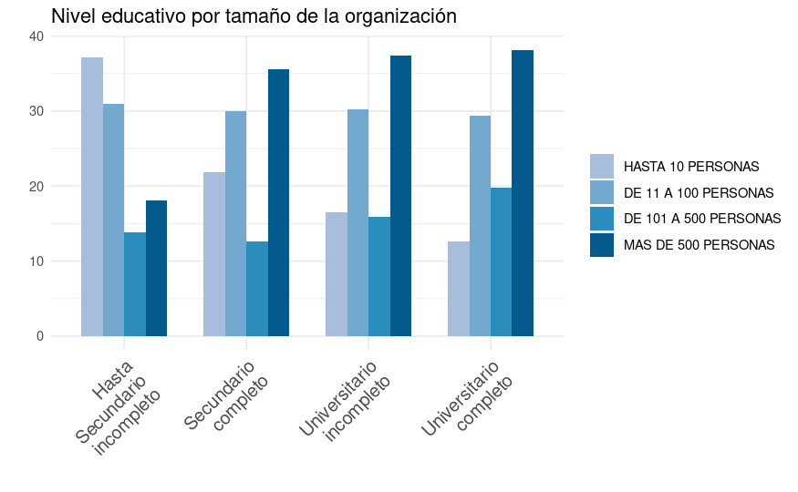

```r
niveled_tam(bases23_rest[[4]])
```

El nivel de educación alcanzado por la población impacta en el puesto de trabajo que es posible obtener. A mayor tamaño de la organización estas van cambiando la composición de su plantilla, siendo necesario que participen cada vez trabajadores calificados, ya sean con título universitario u con este nivel educativo incompleto. Parece que tener más años educativos permite aumentar las probabilidades de acceder a grandes organizaciones. Lo cual parece consistente desde el punto de vista empresarial pues si se quiere ampliar el tamaño de la plantilla es probable que se deba contratar personal cualificado.

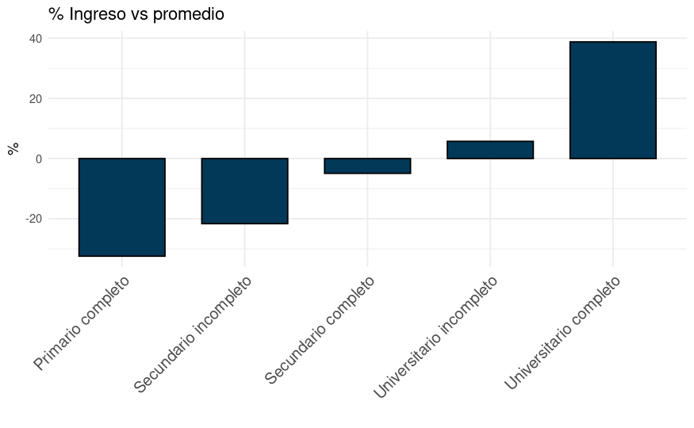

```r
IN_graph(bases23_rest[[4]])
```

Observamos que el nivel educativo es crucial para medir los ingresos de los asalariados. Mientras que quienes solamente terminaron el nivel primario o no terminaron el nivel secundario sus ingresos promedio son 20% inferiores o más, los que completaron sus estudios universitarios tienen ingresos promedio 40% mayores que la media. Se debe tener en cuenta que debido al problema de sub-declaración de ingresos de esta encuesta las brechas posiblemente sean aún mayores.

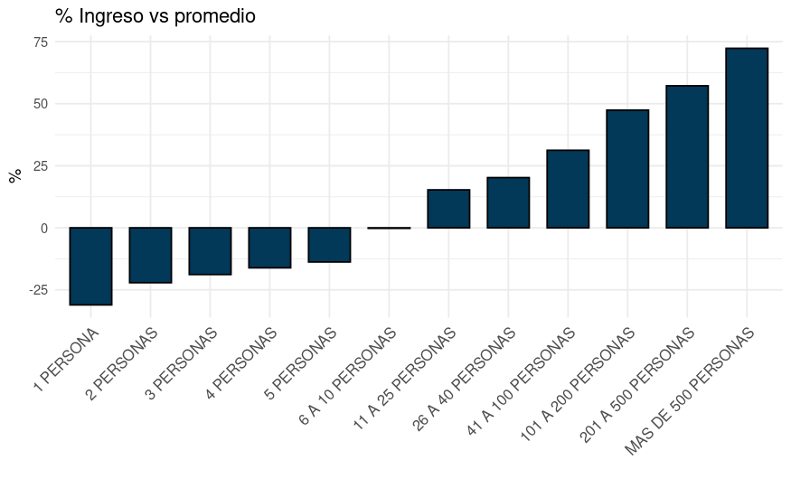

```r
IC_graph(bases23_rest[[4]])
```

### **Objetivo**

En este análisis se pone el foco en explorar cómo el nivel educativo influye en los ingresos laborales en el mercado argentino. El objetivo principal es cuantificar el impacto de la educación, considerando además otras variables relevantes como la edad, la experiencia potencial, el tiempo dedicado al trabajo y el tamaño de la organización a la que pertenecen.

La base teórica de este análisis parte de una premisa ampliamente respaldada en la literatura, un mayor nivel educativo no solo incrementa las oportunidades laborales, sino que también mejora la calidad del empleo y los ingresos percibidos.

En el contexto del mercado laboral argentino, es particularmente relevante analizar estas relaciones, dado que las diferencias educativas suelen estar asociadas a desigualdades salariales significativas. Al mismo tiempo, existen disparidades regionales y urbanas que influyen en la calidad del empleo y en los niveles de ingreso de la población ocupada. Este análisis busca no solo aportar evidencia empírica sobre el impacto de la educación en los salarios, sino también destacar las posibles desigualdades presentes entre distintos grupos.

Con este análisis, se espera aportar claridad sobre cómo el nivel educativo afecta los ingresos laborales en términos cuantitativos y cómo este impacto puede variar entre los diferentes sectores de la población argentina.

### **Modelado**

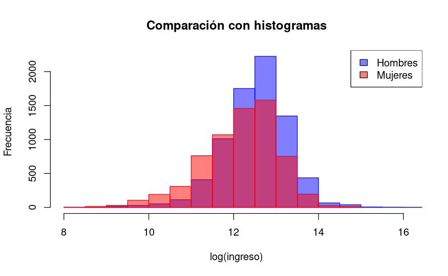

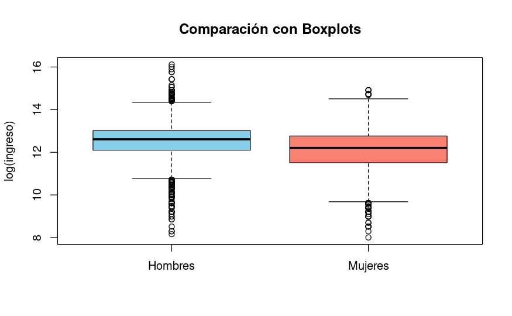

```r
comparacion(bases24_rest)
```

En el histograma vemos que el log(ingreso) de ahora en más `l_i`, para ambos casos parecen seguir una distribución normal, aun que no tienen la misma varianza, no se harán test de normalidad debido a la cantidad de estudios que hay de este dato, de hecho seguiremos la función de ganancia de Mincer que involucra esta transformación del ingreso. Por otro lado, el boxplot vemos que `l_i` de los hombres en promerio es mayor que el sexo opuesto, tambien observamos que la varianza parece ser mayor en las mujeres.

Siguiendo la función de ganancia de `Mincer`, modelamos el efecto de la educación sobre la media del logaritmo de los ingresos de la ocupación principal, controlando con el tamaño de la organización (variable categórica), experiencia potencial, estado civil, logaritmo de horas mensuales trabajadas y experiencia potencial al cuadrado, fue incorporada para observar el efectos no lineal de sus variaciones.

Una desventaja del mismo es la linealidad o no de *anios_edu*, para ellos consideremos un segundo modelo donde representemos la educación con una variable dummy que determina el máximo nivel educativo alcanzado.

##### **Modelo 1**

$$\text{log(ingreso)} = \text{anios_edu} +
\text{exp_pot} + \text{exp_pot}^2 + \text{tamaño organizacion (dummie)}
+ \text{log_horas}$$

##### **Modelo 2**

$$\text{log(ingreso)} = \text{nivel_ed
(dummie)} + \text{exp_pot} + \text{exp_pot}^2 + \text{tamaño
organizacion (dummie)} + \text{log_horas}$$

### **Regresión**

#### **Género Femenino**

Comenzamos con el género femenino

```r
base24_1_fem  <- f_restricciones(bases24[[1]], gender = "fem", asalariado = TRUE)

reg1_f <- lm(log(ingreso)~ anios_edu + exp_pot + exp_pot_2 + as.factor(PP04C) + log_horas, data = base24_1_fem)
reg2_f <- lm(log(ingreso)~ as.factor(NIVEL_ED) + exp_pot + exp_pot_2 + as.factor(PP04C) + log_horas, data = base24_1_fem)

summ_reg1_f <- summary(reg1_f)
summ_reg2_f <- summary(reg2_f)

# Extraer los coeficientes, errores estándar, valores t y p-valores del resumen del modelo
coef_reg1_f <- coef(summ_reg1_f)
coef_reg2_f <- coef(summ_reg2_f)

# Filtrar las filas de los coeficientes que nos interesan
coef_interes_reg1_f <- coef_reg1_f[c("anios_edu", "exp_pot"), ]
coef_interes_reg2_f <- coef_reg2_f[grep("NIVEL_ED", rownames(coef_reg2_f)), ]
```

#### **Efecto no lineal de la educación en el retorno económico**

Graficamos la estimación y su p-valor correspondiente del máximo nivel educativo alcanzado.

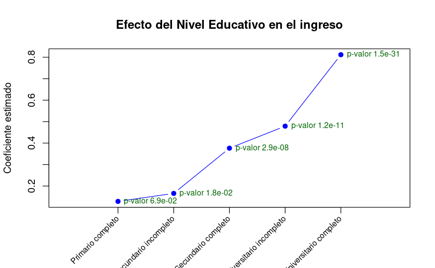

```r
graph_nivel_ed(coef_interes_reg2_f[,1], coef_interes_reg2_f[,4])
```

La variación de los coeficientes de la variable dummy **NIVEL_ED**, sugiere que el efecto en **log(ingreso)** de cada nivel educativo no es constante. Es decir, parece haber un efecto no lineal de la educación.

El retorno económico de completar un nivel educativo cambia significativamente dependiendo de qué nivel se está comparando. Por ejemplo, pasar de primario completo a secundario completo tiene un retorno significativamente mayor, sugiriendo que las personas que completan el secundario pueden obtener un salario más alto que aquellos que sólo completan el primario. Pasar del secundario completo a estudios universitarios completos tiene un incremento aún mayor.

Los coeficientes para secundario completo y universitario incompleto y completo, son todos significativos pues su p-valor es menor a 0.01, además son positivos, lo que respalda la idea de que esos niveles educativos tienen un impacto positivo y relevante en los salarios. Por otro lado, los coeficientes de **Primario completo** y **Secundario incompleto** son similares, no son significativos, ya que su p-valor son mayores a 0.01, en tanto no son “influyentes” para estimar **log(ingreso)**.

La variación en los coeficientes y su significancia sugiere que el impacto de la educación en los salarios no es lineal. Esto es consistente con la idea de que ciertos niveles de educación (como completar la secundaria o la educación superior) ofrecen ventajas salariales más significativas que simplemente tener un año más de educación.

### ANOVA

```r
anova(reg1_f,reg2_f)
```

```
Analysis of Variance Table

Model 1: log(ingreso) ~ anios_edu + exp_pot + exp_pot_2 + as.factor(PP04C) +
    log_horas
Model 2: log(ingreso) ~ as.factor(NIVEL_ED) + exp_pot + exp_pot_2 + as.factor(PP04C) +
    log_horas
  Res.Df    RSS Df Sum of Sq     F    Pr(>F)
1   6496 3258.1
2   6492 3248.7  4    9.4237 4.708 0.0008574 ***
---
Signif. codes:  0 ‘***’ 0.001 ‘**’ 0.01 ‘*’ 0.05 ‘.’ 0.1 ‘ ’ 1
```

Bajo las hipótesis de la prueba *ANOVA* de ambos modelos, vemos un p-valor menor a 0.01, en tanto controlando por las variables control (valga la redundancia) el nivel educativo máximo alcanzado como variable dummie de cada individuo resulta significativo, contra la variable continua. Esto refuerza la idea de que hay un efecto no lineal de la educación en los ingresos.

### **Heterogeneidad en el retorno de la educación | Regresión cuantilica**

El uso de regresiones por cuantiles permite capturar cómo el efecto marginal de los años de educación (**anios_edu**) sobre el logaritmo del ingreso varía a lo largo de la distribución de ingresos. Esto es especialmente relevante para entender cómo la educación afecta de manera diferenciada a mujeres asalariadas en distintos niveles de ingreso, desde las que se encuentran en sectores más vulnerables (cuantiles bajos) hasta las que ocupan posiciones más privilegiadas en términos de ingresos (cuantiles altos).

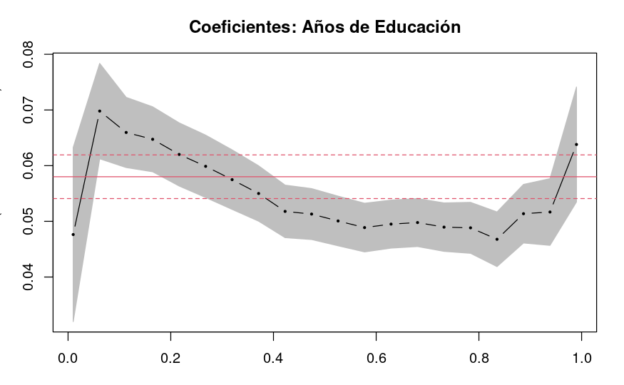

```r
taus = seq(0.01, 0.99, length.out = 20)
regq1_fem <- rq(log(ingreso)~ anios_edu + exp_pot + exp_pot_2 + as.factor(PP04C) + log_horas,data=base24_1_fem,tau = taus,ci = FALSE)
summregq1_fem <- summary(regq1_fem,se="ker")

plot(summregq1_fem, parm =2,
     main = "Coeficientes: Años de Educación", xlab = "Tau (Cuantiles)", ylab = "Coeficientes (Años de Educación)")
```

**Cuantiles bajos (τ < 0.3): Mayor impacto de la educación en ingresos bajos** Para los sectores con ingresos más bajos (τ entre 0.01 y 0.3), el coeficiente estimado de anios_edu muestra un comportamiento creciente, pasando de 0.05 a 0.07 a medida que τ aumenta hasta 0.1. Esto indica que el impacto marginal de la educación es mayor para las mujeres con menores ingresos.

Es decir, en este segmento de la distribución, cada año adicional de educación está asociado con un **aumento del salario** de aproximadamente un **7%**. Esto podría explicarse por el hecho de que la educación en este grupo tiene un efecto significativo en la mejora de oportunidades laborales, facilitando la movilidad económica y el acceso a mejores empleos.

**Cuantiles medios (0.3 ≤ τ < 0.8): Disminución del efecto marginal** Para los cuantiles intermedios, el coeficiente de `anios_edu` comienza a decrecer progresivamente, lo que sugiere que la educación sigue siendo un factor relevante en la determinación de los ingresos, pero su impacto marginal se reduce.

Este fenómeno podria indicar que, para mujeres con ingresos en la mediana de la distribución, otros factores comienzan a jugar un papel más importante en la determinación salarial. Algunos de estos factores pueden incluir la experiencia laboral acumulada, el tipo de ocupación, el tamaño de la organización en la que trabajan, las redes de contacto o la presencia en sectores con mayores barreras de acceso.

En este grupo, cada año adicional de educación está asociado con un **aumento promedio** del salario del **5%**.

Para este segmento, el **retorno marginal** de la educación se mantiene alrededor del **6.3%** por cada anio, lo que sugiere que, si bien la educación sigue influyendo en los ingresos, otras variables como la ocupación, el sector laboral y la posición jerárquica dentro de una organización pueden ser más determinantes en este nivel de la distribución.

### **Sesgo de seleccion | Metodo Heckman**

Al trabajar con salarios de la población femenina, es importante considerar si existe un sesgo muestral debido a la decisión de participar en el mercado laboral. Muchas mujeres enfrentan un “salario de reserva”, determinado por el valor que atribuyen a actividades fuera del mercado, como el cuidado del hogar o la crianza de los hijos. Si el salario de mercado no supera ese valor, no participan en el mercado laboral, lo que genera un sesgo de selección en los datos observados. Este sesgo puede hacer que el salario promedio de las mujeres en la muestra sea menor al que sería si toda la población estuviera incluida.

Dado este contexto, utilizó el método de Heckman para ajustar por sesgo de selección y evaluar si la influencia de la educación cambia sustancialmente al corregir este sesgo. Además posteriormente, empleo la descomposición de Oaxaca-Blinder para analizar si existe discriminación salarial entre hombres y mujeres, considerando tanto las características observables como las diferencias en cómo el mercado valora estas características.

#### **Modelo de seleccion**

Para modelar la decisión de trabajar voy a tener en cuenta:

- **edad y $edad ^ 2$:** para capturar los efectos no lineales de sus variaciones. Se espera que los coeficientes tengan signo positivo y negativo respectivamente, ya que a mayor edad mayor será la probabilidad de que la mujer participe en el mercado laboral pero alcanzará un valor máximo de probabilidad, a partir del cual comenzará a disminuir.
- **nivel_ed:** Se espera que sea positivo.
- **ingreso del jefe de familia**: Fue definido como el ingreso que percibe la persona que el grupo familiar considera como jefe de familia y se espera una relación inversa entre dicha variable y la probabilidad de participar en el mercado laboral de la mujer.
- **estrato:** Se tuvo en cuenta la distribución del ingreso de la ciudad calculada por deciles de ingreso familiar. En base a la misma, se denominó Est1, a los niveles correspondientes a los 3 deciles más bajos; Est2 a los niveles comprendidos desde el cuarto al noveno decil y finalmente Est3 al último.
- **# integrantes:** En el modelo se incorporó el tamaño del hogar para captar de esta forma, el compromiso de la mujer en el cuidado de los miembros. A medida que aumenta el número de integrantes en la familia disminuye la probabilidad de participación de la mujer en el mercado laboral, su costo de oportunidad es mayor por lo cual también su salario de reserva.

Se tuvieron en cuenta variables como el estado civil, la existencia o no de otros perceptores de ingreso en la familia, pero se optó por los anteriores porque no mejoraba las predicciones de forma sustancial.

$$\text{Desicion} = \text{edad} +
\text{edad}^2 + \text{nivel_ed (dummie)} + \text{ingreso jefe familia} +
\text{# integrantes} + \text{estrato (dummie)}$$

```r
aux <- f_restricciones(bases24[[1]], gender = "fem", asalariado = FALSE)
aux <- mergear(aux, hogares24[[1]], bases24[[1]])
base24_1_fem_hm <- Heckman_method(aux)

rm(aux)

# Ajustar el modelo principal con lambda
heckman_fem_24 <- lm(log(ingreso) ~ anios_edu + exp_pot + exp_pot_2 + as.factor(PP04C) + log_horas + lambda,
                     data = base24_1_fem_hm %>% filter(ingreso>0))

summary(heckman_fem_24)
```

```
Call:
lm(formula = log(ingreso) ~ anios_edu + exp_pot + exp_pot_2 +
    as.factor(PP04C) + log_horas + lambda, data = base24_1_fem_hm %>%
    filter(ingreso > 0))

Residuals:
    Min      1Q  Median      3Q     Max
-3.6528 -0.3932  0.0441  0.4401  3.7626

Coefficients:
                     Estimate Std. Error t value Pr(>|t|)
(Intercept)         1.040e+01  6.993e-02 148.659  < 2e-16 ***
anios_edu           5.299e-02  2.676e-03  19.803  < 2e-16 ***
exp_pot             1.134e-02  3.196e-03   3.546 0.000394 ***
exp_pot_2          -2.203e-04  6.743e-05  -3.267 0.001095 **
as.factor(PP04C)1   2.117e-01  3.626e-02   5.837 5.65e-09 ***
as.factor(PP04C)2   4.363e-01  4.676e-02   9.332  < 2e-16 ***
as.factor(PP04C)3   6.308e-01  6.108e-02  10.327  < 2e-16 ***
as.factor(PP04C)4   5.481e-01  7.077e-02   7.745 1.16e-14 ***
as.factor(PP04C)5   7.942e-01  6.539e-02  12.147  < 2e-16 ***
as.factor(PP04C)6   7.745e-01  4.468e-02  17.334  < 2e-16 ***
as.factor(PP04C)7   9.866e-01  4.341e-02  22.726  < 2e-16 ***
as.factor(PP04C)8   9.888e-01  4.359e-02  22.683  < 2e-16 ***
as.factor(PP04C)9   1.061e+00  4.299e-02  24.676  < 2e-16 ***
as.factor(PP04C)10  1.163e+00  5.069e-02  22.941  < 2e-16 ***
as.factor(PP04C)11  1.134e+00  5.780e-02  19.617  < 2e-16 ***
as.factor(PP04C)12  1.155e+00  5.430e-02  21.266  < 2e-16 ***
as.factor(PP04C)99  7.743e-01  4.462e-02  17.354  < 2e-16 ***
log_horas           8.209e-02  6.004e-03  13.673  < 2e-16 ***
lambda             -6.573e+00  4.037e-01 -16.283  < 2e-16 ***
---
Signif. codes:  0 ‘***’ 0.001 ‘**’ 0.01 ‘*’ 0.05 ‘.’ 0.1 ‘ ’ 1

Residual standard error: 0.6877 on 4889 degrees of freedom
Multiple R-squared:  0.4146,    Adjusted R-squared:  0.4124
F-statistic: 192.3 on 18 and 4889 DF,  p-value: < 2.2e-16
```

Como la nueva variable $\lambda$ resulta significativa podemos concluir que exite sesgo de selección y en este caso, los coeficientes que intervendrán en el cálculo de la discriminación serán los “corregidos” por sesgo, es decir los que resultan de la última ecuación.

Dadas las condiciones teóricas del método de Heckman, vamos a emplearlo en rehacer el gráfico previo:

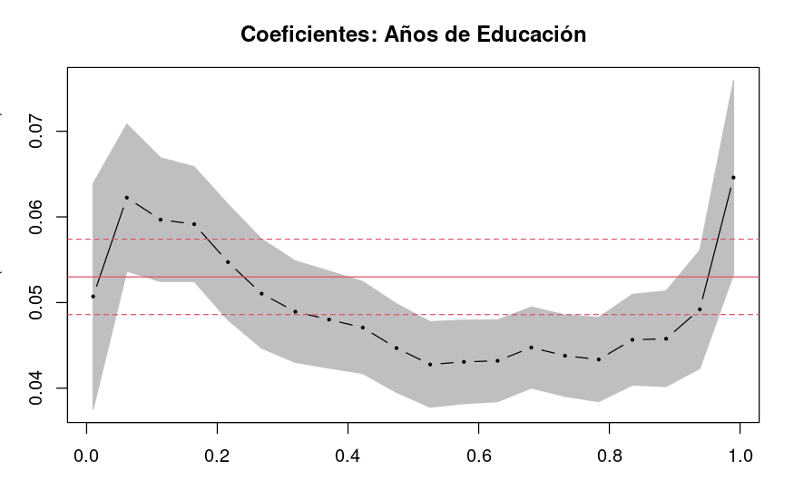

```r
heckman_stage2_fem <- rq(log(ingreso)~ anios_edu + exp_pot + exp_pot_2 + as.factor(PP04C) + log_horas + lambda, data=base24_1_fem_hm%>%filter(ingreso>0),tau = taus,ci = FALSE)
summ_heckman_stage2_fem <- summary(heckman_stage2_fem,se="ker")

plot(summ_heckman_stage2_fem, parm =2,
     main = "Coeficientes: Años de Educación", xlab = "Tau (Cuantiles)", ylab = "Coeficientes (Años de Educación)")
```

Observamos que el comportamiento del efecto marginal de la educacion a lo largo de la distribucion no cambio sustancialmente, sin embargo se observa una reduccion tanto en el extremo maximo ahora representa un aumento promedio en el salario del 6.3% (aprox) por cada anio de educacion (cerca $\tau$ = 0.1) y un aumento en el minimo del 6.5% por anio adicional (apartir de $\tau$ = 0.9). Ademas de una reduccion en la mediana de la distribucion, ahora un aumento del 4.5% por cada anio.**En conclucion hubo una leve reduccion en la varianza del efecto marginal a lo largo de la distribucion.**

Al comparar los coeficientes estimados con y sin la corrección de Heckman, observamos que la tendencia general del efecto marginal de la educación a lo largo de la distribución de ingresos no cambia sustancialmente. Sin embargo, se presentan algunas diferencias clave:

- **En los cuantiles bajos (τ ≈ 0.1)**, el efecto marginal máximo de la educación se reduce, pasando de un incremento del **7% a un 6.3% en el ingreso por cada año adicional de educación**.
- **En los cuantiles altos (τ ≈ 0.9)**, el efecto marginal mínimo de la educación aumenta, pasando de **6.3% a 6.5% por año adicional de educación**.
- **En la mediana de la distribución (τ = 0.5)**, el coeficiente disminuye, reflejando un efecto marginal del **4.5% por año de educación**, en comparación con el 5% estimado sin la corrección de Heckman.

Tras aplicar la corrección por sesgo de selección, se observa una leve reducción en la varianza del efecto marginal de la educación a lo largo de la distribución de ingresos. Esto sugiere que el sesgo de selección afectaba principalmente a los cuantiles extremos, lo que podría haber sobrestimado la heterogeneidad en los retornos educativos.

Estos resultados refuerzan la idea de que la educación sigue desempeñando un papel clave en la determinación del ingreso, aunque su impacto puede estar condicionado por factores no observados en la selección de la muestra.

### **Género Masculino**

```r
base24_1_mas <- f_restricciones(bases24[[1]],gender = "mas", asalariado = TRUE)

reg1 <- lm(log(ingreso) ~ anios_edu + exp_pot + exp_pot_2 + as.factor(PP04C) + log_horas, data = base24_1_mas)
reg2 <- lm(log(ingreso) ~ as.factor(NIVEL_ED) + exp_pot + exp_pot_2 + as.factor(PP04C) + log_horas, data = base24_1_mas)

summ_reg1 <- summary(reg1)
summ_reg2 <- summary(reg2)

# Extraer los coeficientes, errores estándar, valores t y p-valores del resumen del modelo
coef_reg1 <- coef(summ_reg1)
coef_reg2 <- coef(summ_reg2)

# Filtrar las filas de los coeficientes que te interesan
coef_interes_reg1_m <- coef_reg1[c("anios_edu"), ]
coef_interes_reg2_m <- coef_reg2[grep("NIVEL_ED", rownames(coef_reg2)), ]
```

#### **Efecto no lineal de la educación en el retorno económico**

Graficamos el coeficiente estimado, con el p-valor correspondiente de “Nivel Educativo”, del 2do modelo.

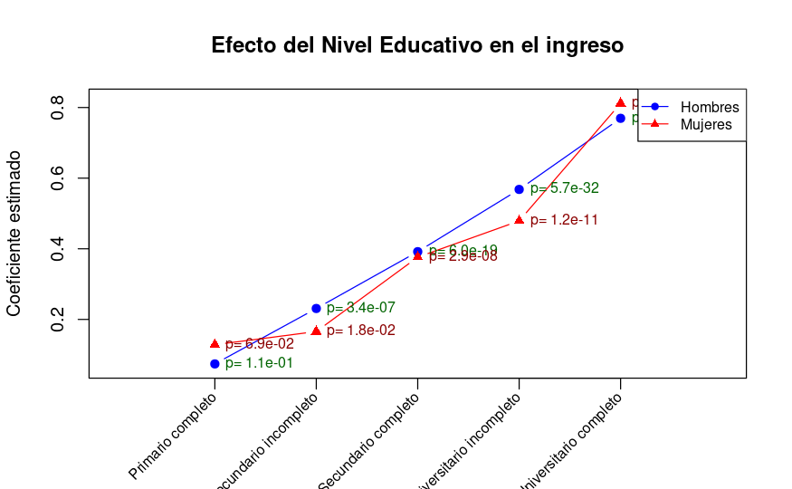

```r
graph_nivel_ed_comparacion(coef_interes_reg2_m[,1], coef_interes_reg2_m[,4], coef_interes_reg2_f[,1], coef_interes_reg2_f[,4])
```

Se observa un comportamiento casi perfectamente lineal para el género masculino, no parece haber una diferencia evidente en el retorno de la educación.

```r
# Definir los valores a mostrar
diferencia_coef <- coef_interes_reg2_f[,1] - coef_interes_reg2_m[,1]
# Crear una tabla con una sola fila
tabla <- data.frame(matrix(diferencia_coef, nrow = 1, dimnames = list("Diferencia", x)))
print(tabla)
```

|  | Primario.completo | Secundario.incompleto | Secundario.completo | Universitario.incompleto | Universitario.completo |
| --- | --- | --- | --- | --- | --- |
| Diferencia | 0.05450233 | -0.06527454 | -0.01555879 | -0.08911788 | 0.0423752 |

Para los “extremos”, es decir **primario completo** y **universitario completo** se observa una ligera ventaja a favor del género femenino, la influencia del máximo nivel educativo alcanzado es menor para los hombres, hay una diferencia cerca del .05. Para los demás niveles educativos se observa una ventaja en el género masculino, para **secundario incompleto** y **universitario incompleto** hay una diferencia del .06 y.09 respectivamente, esto es que los hombres reciben un .06 más de retorno que las mujeres.

### ANOVA

Realizamos nuevamente la prueba ANOVA como una prueba rigurosa de la no linearildad de la educacion.

```r
anova(reg1,reg2)
```

```
Analysis of Variance Table

Model 1: log(ingreso) ~ anios_edu + exp_pot + exp_pot_2 + as.factor(PP04C) +
    log_horas
Model 2: log(ingreso) ~ as.factor(NIVEL_ED) + exp_pot + exp_pot_2 + as.factor(PP04C) +
    log_horas
  Res.Df    RSS Df Sum of Sq   F  Pr(>F)
1   7493 3337.0
2   7489 3332.1  4    4.8054 2.7 0.02898 *
---
Signif. codes:  0 ‘***’ 0.001 ‘**’ 0.01 ‘*’ 0.05 ‘.’ 0.1 ‘ ’ 1
```

Bajo las hipotesis de la prueba *ANOVA* de ambos modelos, vemos un p-valor al rededor de .028, por lo tanto para este caso no hay pruebas suficientes para descartar el primer modelo.

### Heterogeneidad en el retorno de la educación | Regresion cuantilica

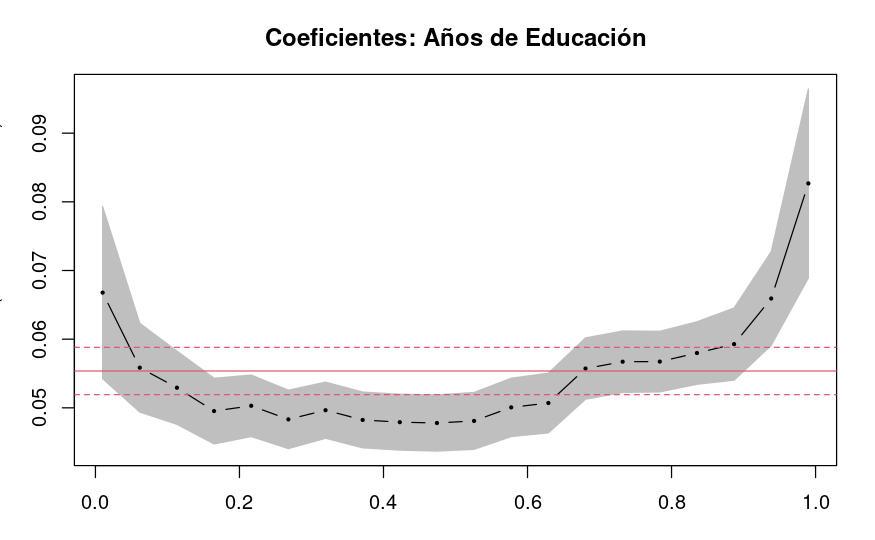

```r
regq1 <- rq(log(ingreso) ~ anios_edu + exp_pot + exp_pot_2 + as.factor(PP04C) + log_horas, data=base24_1_mas, tau = taus, ci = FALSE)
summregq1 <- summary(regq1,se="ker")

plot(summregq1,parm =2,
     main = "Coeficientes: Años de Educación", xlab = "Tau (Cuantiles)", ylab = "Coeficientes (Años de Educación)")
```

**Cuantiles bajos (τ < 0.1)** En los sectores de ingresos más bajos, el coeficiente de `anios_edu` se sitúa alrededor de 0.07, lo que indica que *cada año adicional de educación* está asociado con un *aumento del 7%* en los ingresos.

Esto sugiere que, para los trabajadores con menores ingresos, la educación tiene un impacto significativo en la movilidad económica. Dado que estos individuos suelen estar en sectores laborales con menor estabilidad y salarios más bajos, el aumento del capital humano a través de la educación podría representar una vía clave para mejorar su situación económica.

Esto indica que el impacto de la educación es menos pronunciado en la mediana de los ingresos. A este nivel, otros factores como la experiencia laboral, la red de contactos o la especialización podrían jugar un rol más determinante en la remuneración de los trabajadores.

**Cuantiles altos (τ > 0.8)** En los sectores de ingresos más altos, el coeficiente de `anios_edu` vuelve a *aumentar hasta 0.085 (8.5%)*.

Esto sugiere que, en los niveles superiores de la distribución de ingresos, la educación sigue desempeñando un papel clave en la determinación del salario. Es posible que esto refleje la importancia de la acumulación de capital humano especializado, credenciales avanzadas y posiciones laborales que requieren títulos educativos más altos. Conclusión

El análisis revela una relación no uniforme entre la educación y los ingresos.

### **Sesgo de seleccion | Metodo Heckman | Hombres**

En este análisis, se aplica la corrección por sesgo de selección mediante el método de Heckman solo en la estimación de ingresos para las mujeres. Esto se debe a que las mujeres suelen enfrentar mayores barreras para ingresar al mercado laboral, lo que genera una autoexclusión no aleatoria y puede sesgar las estimaciones del efecto de la educación sobre los ingresos.

En el caso de los hombres, aunque el coeficiente $\lambda$ es estadísticamente significativo, las tasas de participación laboral son mas altas, la selección en el mercado laboral masculino es menos restrictiva y la autoexclusión del mismo no sigue el mismo patrón sistemático que en las mujeres, considero que su interpretabilidad es menos clara y por lo tanto no usare el metodo.

De todas formas dejo el código del mismo:

```r
base24_1_mas_hm <- f_restricciones(bases24[[1]], gender = "mas", asalariado = FALSE)
base24_1_mas_hm <- mergear(base24_1_mas_hm, hogares24[[1]], bases24[[1]])
base24_1_mas_hm <- Heckman_method(base24_1_mas_hm)
```

```r
# Ajustar el modelo principal con lambda
heckman_stage2 <- lm(log(ingreso) ~ anios_edu + exp_pot + exp_pot_2 + as.factor(PP04C) + log_horas + lambda,
                     data = base24_1_mas_hm %>% filter(ingreso>0))

# Resumen del modelo
summary(heckman_stage2)
```

```
Call:
lm(formula = log(ingreso) ~ anios_edu + exp_pot + exp_pot_2 +
    as.factor(PP04C) + log_horas + lambda, data = base24_1_mas_hm %>%
    filter(ingreso > 0))

Residuals:
    Min      1Q  Median      3Q     Max
-3.9413 -0.3362  0.0248  0.3839  3.5378

Coefficients:
                     Estimate Std. Error t value Pr(>|t|)
(Intercept)         1.100e+01  1.613e-01  68.156  < 2e-16 ***
anios_edu           3.307e-02  2.354e-03  14.049  < 2e-16 ***
exp_pot             9.544e-03  2.913e-03   3.277  0.00106 **
exp_pot_2          -2.327e-04  5.580e-05  -4.171 3.08e-05 ***
as.factor(PP04C)1   6.033e-01  1.493e-01   4.041 5.40e-05 ***
as.factor(PP04C)2   6.940e-01  1.506e-01   4.608 4.15e-06 ***
as.factor(PP04C)3   8.073e-01  1.525e-01   5.292 1.25e-07 ***
as.factor(PP04C)4   8.906e-01  1.549e-01   5.750 9.42e-09 ***
as.factor(PP04C)5   9.428e-01  1.553e-01   6.072 1.35e-09 ***
as.factor(PP04C)6   9.859e-01  1.509e-01   6.535 6.94e-11 ***
as.factor(PP04C)7   1.091e+00  1.509e-01   7.228 5.56e-13 ***
as.factor(PP04C)8   1.125e+00  1.515e-01   7.429 1.26e-13 ***
as.factor(PP04C)9   1.191e+00  1.507e-01   7.906 3.19e-15 ***
as.factor(PP04C)10  1.232e+00  1.520e-01   8.105 6.43e-16 ***
as.factor(PP04C)11  1.350e+00  1.528e-01   8.835  < 2e-16 ***
as.factor(PP04C)12  1.368e+00  1.521e-01   8.993  < 2e-16 ***
as.factor(PP04C)99  1.017e+00  1.500e-01   6.778 1.35e-11 ***
log_horas           5.192e-02  6.042e-03   8.592  < 2e-16 ***
lambda             -1.179e+01  4.383e-01 -26.907  < 2e-16 ***
---
Signif. codes:  0 ‘***’ 0.001 ‘**’ 0.01 ‘*’ 0.05 ‘.’ 0.1 ‘ ’ 1

Residual standard error: 0.6275 on 5601 degrees of freedom
Multiple R-squared:  0.3313,    Adjusted R-squared:  0.3291
F-statistic: 154.1 on 18 and 5601 DF,  p-value: < 2.2e-16
```

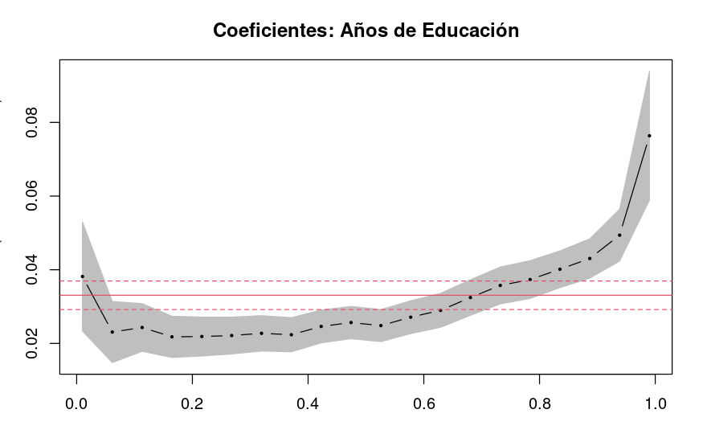

```r
heckman_stage2_mas <- rq(log(ingreso)~ anios_edu + exp_pot + exp_pot_2 + as.factor(PP04C) + log_horas + lambda, data=base24_1_mas_hm%>%filter(ingreso>0),tau = taus,ci = FALSE)
summ_heckman_stage2_mas <- summary(heckman_stage2_mas,se="ker")

plot(summ_heckman_stage2_mas, parm =2,
     main = "Coeficientes: Años de Educación", xlab = "Tau (Cuantiles)", ylab = "Coeficientes (Años de Educación)")
```

Luego de aplicar el método Heckman, los valores disminuyeron, ahora la mediana de la distribución sólo tiene un 2% de retorno por año educativo adicional, 4% para la población con menor salario y alrededor del 7% para los asalariados pertenecientes a los cuantiles más altos.

### **Desigualdad en el tiempo | Influencia de la educacion**

```r
bases23_mas <- list()
bases23_fem <- list()
for (i in 1:4) {
  bases23_mas[[i]] <- f_restricciones(bases23[[i]], gender = "mas", asalariado = TRUE)
  bases23_fem[[i]] <- f_restricciones(bases23[[i]], gender = "fem", asalariado = TRUE)
}

bases24_mas <- list()
bases24_fem <- list()

for(i in 1:2){
  bases24_mas[[i]] <- f_restricciones(bases24[[i]], gender = "mas", asalariado = TRUE)
  bases24_fem[[i]] <- f_restricciones(bases24[[i]], gender = "fem", asalariado = TRUE)
}
```

### Índice Gini

El índice fue calculado con el sector asalariado, como se ve para ambos sexos y también por separado. Se tomaron los 4 periodos del año 2023 y los dos primeros del 2024.

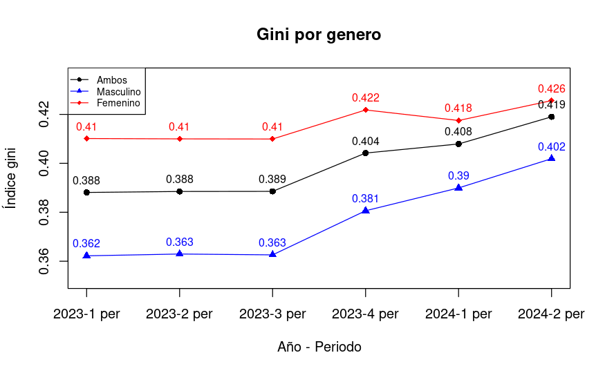

```r
# Inicializar las listas vacías para los tres grupos
ambos <- c()
mas <- c()
fem <- c()

# Calcular el índice de Gini para cada grupo en cada periodo
for(i in 1:4){
  ambos <- c(ambos, Gini(bases23_rest[[i]]$ingreso[bases23_rest[[i]]$ingreso>0]))
  mas   <- c(mas, Gini(bases23_mas[[i]]$ingreso))
  fem   <- c(fem, Gini(bases23_fem[[i]]$ingreso))
}
for(i in 1:2){
  ambos <- c(ambos, Gini(bases24_rest[[i]]$ingreso[bases24_rest[[i]]$ingreso>0]))
  mas   <- c(mas, Gini(bases24_mas[[i]]$ingreso))
  fem   <- c(fem, Gini(bases24_fem[[i]]$ingreso))
}

graph_gini(ambos, mas, fem)
```

La comparación de los valores del índice de Gini entre 2023 y 2024 muestra un aumento de 0.388 a 0.419 para ambos géneros, implica un cambio negativo en términos de equidad, ya que indica una mayor desigualdad en la distribución de los ingresos en la población. Se observa una pendiente más pronunciada en el género masculino aunque sigue siendo el género opuesto más desigual. Es interesante ver que los valores están muy cerca del .5, si bien no están cerca del 1 (desigualdad perfecta) es alarmante ver que no parecen descender en el 2024.

Se observa un aumento generalizado de la desigualdad entre 2023 y 2024.

Para la población total, el índice de Gini aumenta de 0.388 a 0.419, lo que sugiere un deterioro en la equidad de la distribución del ingreso. Este incremento indica que los ingresos en el sector asalariado se han vuelto más desiguales en 2024.

Mujeres: Presentan los mayores niveles de desigualdad en ambos años. En 2023, el índice de Gini ya era superior al de los hombres (0.410 vs. 0.362) y en 2024 la brecha persiste (0.425 vs. 0.401).

Hombres: A pesar de partir de un nivel más bajo de desigualdad, muestran un aumento más pronunciado en la pendiente, lo que sugiere que la distribución del ingreso dentro de este grupo ha empeorado más rápidamente en comparación con las mujeres. Interpretación de los valores:

Aunque los valores no están cerca de 1 (desigualdad total), el hecho de que se mantengan elevados y en ascenso en 2024, indica a una desigualdad mayor. El índice se acerca progresivamente al umbral de 0.5, lo que sugiere una alta concentración de ingresos en ciertos sectores de la población asalariada.

```r
# Definir los valores a mostrar
diferencia_coef <- fem - mas
anio23 <- mean(diferencia_coef[1:4])
anio24 <- mean(diferencia_coef[5:6])

# Crear una tabla con una sola fila
tabla <- data.frame(matrix(diferencia_coef, nrow = 1, dimnames = list("Diferencia", anios)))
tabla
```

|  | X2023.1.per | X2023.2.per | X2023.3.per | X2023.4.per | X2024.1.per | X2024.2.per |
| --- | --- | --- | --- | --- | --- | --- |
| Diferencia | 0.04793072 | 0.04705302 | 0.04734919 | 0.04117871 | 0.02755702 | 0.02372706 |

**Conclusión**

El incremento del índice de Gini entre 2023 y 2024 refleja un deterioro en la equidad salarial dentro del sector asalariado. Las mujeres continúan siendo el grupo con mayor desigualdad, aunque la población masculina experimenta un incremento más acelerado en la desigualdad.

El hecho de que la tendencia no muestre una reversión en 2024 resalta la necesidad de examinar los factores estructurales detrás de estas desigualdades, como la segmentación del mercado laboral, diferencias en la estructura salarial y la evolución de las condiciones económicas.

### Índice Theil

Una propiedad del índice Theil es que se puede establecer una descomposición aditiva en dos componentes. Para conjuntos de subgrupos mutuamente excluyentes, {1,2,…,$G$}, el índice de Theil puede re-expresarse como:

$$T = \sum_{g=1}^{G} \frac{n_g
\mu_g}{n\mu} T_g + \sum_{g=1}^{G}\frac{n_g \mu_g}{n\mu}
ln(\frac{\mu_g}{\mu})$$
De acuerdo a Bourguignon (1979), Cowell (1980) y Shorrocks (1980).

donde:

- $n_g$, es el número de observaciones en el subgrupo $g$.
- $\mu_g$, es el ingreso medio del subgrupo $g$.
- $T_g$, es el índice Theil calculado para el subgrupo $g$.

El primer sumando representa el componente de la desigualdad atribuido a las diferencias de ingresos **dentro** de un mismo grupo. (**within**)

El segundo sumando representa la desigualdad en los ingresos **entre** los subgrupos de la población. (**between**)

A continuación calculamos esta descomposición utilizando como subgrupos los géneros y niveles educativos.

```r
des <- Descomp_Theil(bases23_rest, bases24_rest,'gender')
x_gen <- des$x
w_gen <- des$w
b_gen <- des$b
des <- Descomp_Theil(bases23_fem, bases24_fem,'NIVEL_ED')
x_ed <- des$x
w_ed <- des$w
b_ed <- des$b
rm(des)
```

#### **Por nivel educativo**

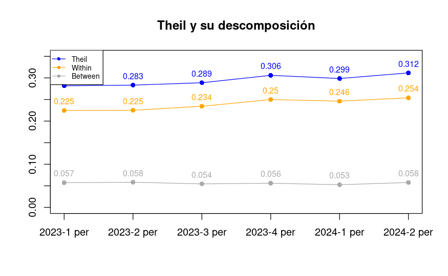

```r
graph_theil(x_ed,w_ed,b_ed)
```

```r
w_ed / x_ed * 100
```

```
[1] 79.69250 79.42534 81.13267 81.67261 82.41461 81.48439
```

```r
b_ed / x_ed * 100
```

```
[1] 20.30750 20.57466 18.86733 18.32739 17.58539 18.51561
```

Observamos una situacion similar a la del Gini, en terminos de un aumento en la desiguldad aun que no parece tan pronunciado, la interpretabilidad de la magnitud de la desigualdad en el Theil es diferente por un tema de escalas, la perfecta desigualdad es del $[ln(n)]$ con n el tamanio de la muestra. Sin embargo, la pendiente de la funcion logaritmo natural cae rapidamente. Esto provoca que esa caracteristica no demasiado deseable resulte de poca importancia practica para muestras como las que utilizamos, lo suficientemente grandes y aproximadamente del mismo tamanio. (entre 14500 y 15000)

Podriamos llevarlo a la escala dividiendo T por [ln(n)] es posible su normalizacion entre 0 y 1. Pero la propiedad de aditividad es la razon por la cual no se normaliza, ademas ya tenemos idea de que hay una evidente desigualdad gracias al indice Gini, por lo tanto nos centramos en la descomposicion como tal.

**Componente Within vs. Between**

La componente **between** es casi constante a lo largo del tiempo, y vemos que la mayor parte del comportamiento de la desigualdad salarial se le atribuye a la componente **within**. La desigualdad salarial dentro de los niveles educativos (“Within”) representa en promedio el 80% de la desigualdad total.

Esto indica que, incluso dentro de cada nivel educativo, existen diferencias salariales significativas. + La heterogeneidad dentro de cada grupo educativo es el principal determinante de la desigualdad. + La desigualdad entre niveles educativos (“Between”) contribuye con el 20% restante.

Esto sugiere que la diferencia en ingresos entre personas con distintos niveles educativos explica solo una fracción menor de la desigualdad total.

Tendencia temporal:

En el cuarto trimestre de 2023, se observa un aumento en la desigualdad salarial. Este incremento es impulsado principalmente por la desigualdad dentro de los niveles educativos, lo que implica que las diferencias salariales entre personas con la misma educación se ampliaron.

**Conclusión**

La mayor parte de la desigualdad salarial proviene de diferencias dentro de cada nivel educativo, no entre ellos. Aunque el nivel educativo es un factor importante para explicar las diferencias salariales, existen otros factores que generan desigualdad dentro de cada grupo educativo (por ejemplo, experiencia, tipo de empleo, sector económico y género). Si bien la desigualdad entre niveles educativos es relevante, las diferencias salariales dentro de cada nivel educativo son las que realmente impulsan la desigualdad total en el mercado laboral asalariado.

#### **Por genero**

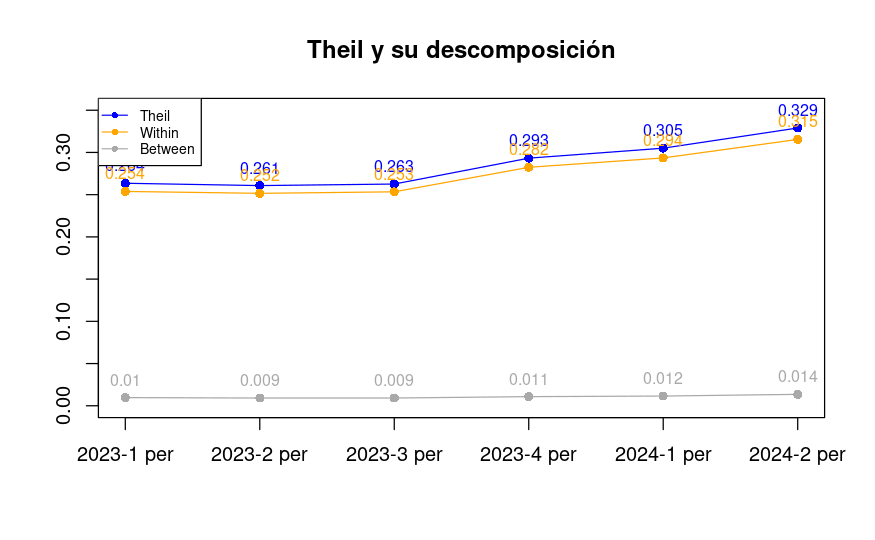

```r
graph_theil(x_gen,w_gen,b_gen)
```

```r
w_gen / x_gen * 100
```

```
[1] 96.32880 96.48020 96.49607 96.31150 96.22109 95.88536
```

```r
b_gen / x_gen * 100
```

```
[1] 3.671200 3.519798 3.503935 3.688496 3.778912 4.114643
```

El comportamiento observado es similar al análisis por nivel educativo, con la diferencia de que ahora la componente within representa el 96% de la desigualdad total, lo que indica que la mayor parte de la desigualdad salarial se debe a diferencias dentro de cada género, más que a la brecha salarial entre hombres y mujeres.

No obstante, la desigualdad entre géneros (“Between”) ha aumentado, lo que indica que la brecha salarial de género ha empeorado en este período.

**Componente Within vs. Between**

La desigualdad *dentro* de cada grupo de género (“Within”) *explica casi la totalidad de la desigualdad salarial (96%)*.

Esto indica que, más allá de la brecha salarial entre hombres y mujeres, *existen diferencias salariales* significativas *dentro* de cada grupo. Es probable que factores como el sector de empleo, la ocupación, la antigüedad y la negociación salarial tengan un rol clave en esta heterogeneidad. La desigualdad entre géneros (“Between”) ha aumentado ligeramente, alcanzando el *4.11%* en el primer semestre de 2024.

Esto refleja un incremento en las disparidades salariales de género, lo que indica que las diferencias en la remuneración entre hombres y mujeres se han acentuado en el último período. Evolución temporal:

La desigualdad de género se mantiene baja en términos relativos, pero su tendencia al alza en los últimos trimestres sugiere un deterioro en la equidad salarial entre hombres y mujeres. Conclusión La desigualdad salarial en Argentina no se explica principalmente por la brecha de género, sino por las diferencias dentro de cada grupo de género. Las diferencias salariales entre hombres y mujeres han aumentado en el último año, lo que sugiere que las barreras de género en el mercado laboral siguen siendo un factor relevante. Para reducir la desigualdad salarial total, se deben abordar tanto las diferencias dentro de cada grupo (por ejemplo, mejorando las condiciones laborales y la movilidad laboral) como las diferencias entre géneros (reduciendo la brecha salarial y promoviendo igualdad de oportunidades en el acceso a mejores empleos).

### **Cuantificación de la influencia de la educación**

Para ello vamos a realizar la regresión RIF (recenter influence function). Hacemos el cálculo de RIF de `log(ingreso)`, usando como estadístico el índice de Gini, para luego estimar los coeficientes resultantes de la regresión, tomando **anios_edu**.

```r
d1 <- bases23_mas
d2 <- bases23_fem
d3 <- bases23_rest

coefs_rif_edu_mas <- c()
coefs_rif_edu_fem <- c()
coefs_rif_edu <- c()
#coefs_rif_exp <- c()

for(i in 1:4){
  # calculamos RIF en funcion de lwage.
  rif_gini_mas <- rif(log(d1[[i]]$ingreso[d1[[i]]$ingreso >0]), method = "gini")
  rif_gini_fem <- rif(log(d2[[i]]$ingreso[d2[[i]]$ingreso >0]), method = "gini")
  rif_gini <- rif(log(d3[[i]]$ingreso[d3[[i]]$ingreso >0]), method = "gini")

  RIFreg_gini_mas <- lm(rif_gini_mas ~ anios_edu + exp_pot + exp_pot_2 + as.factor(PP04C) + log_horas, data = d1[[i]] %>% filter(ingreso >0))
  RIFreg_gini_fem <- lm(rif_gini_fem ~ anios_edu + exp_pot + exp_pot_2 + as.factor(PP04C) + log_horas, data = d2[[i]] %>% filter(ingreso >0))
  RIFreg_gini     <- lm(rif_gini     ~ anios_edu + exp_pot + exp_pot_2 + as.factor(PP04C) + log_horas, data = d3[[i]] %>% filter(ingreso >0))

  edu1 <- RIFreg_gini_mas$coefficients[2]
  edu2 <- RIFreg_gini_fem$coefficients[2]
  edu3 <- RIFreg_gini$coefficients[2]
  #exp <- RIFreg_gini$coefficients[3]

  coefs_rif_edu_mas <- c(coefs_rif_edu_mas, edu1)
  coefs_rif_edu_fem <- c(coefs_rif_edu_fem, edu2)
  coefs_rif_edu <- c(coefs_rif_edu, edu3)
  #coefs_rif_exp <- c(coefs_rif_exp, exp)
}

d1 <- bases24_mas
d2 <- bases24_fem
d3 <- bases24_rest

for(i in 1:2){
  # calculamos RIF en funcion de lwage.
  rif_gini_mas <- rif(log(d1[[i]]$ingreso[d1[[i]]$ingreso >0]), method = "gini")
  rif_gini_fem <- rif(log(d2[[i]]$ingreso[d2[[i]]$ingreso >0]), method = "gini")
  rif_gini <- rif(log(d3[[i]]$ingreso[d3[[i]]$ingreso >0]), method = "gini")

  RIFreg_gini_mas <- lm(rif_gini_mas ~ anios_edu + exp_pot + exp_pot_2 + as.factor(PP04C) + log_horas, data = d1[[i]] %>% filter(ingreso >0))
  RIFreg_gini_fem <- lm(rif_gini_fem ~ anios_edu + exp_pot + exp_pot_2 + as.factor(PP04C) + log_horas, data = d2[[i]] %>% filter(ingreso >0))
  RIFreg_gini     <- lm(rif_gini     ~ anios_edu + exp_pot + exp_pot_2 + as.factor(PP04C) + log_horas, data = d3[[i]] %>% filter(ingreso >0))

  edu1 <- RIFreg_gini_mas$coefficients[2]
  edu2 <- RIFreg_gini_fem$coefficients[2]
  edu3 <- RIFreg_gini$coefficients[2]
  #exp <- RIFreg_gini$coefficients[3]

  coefs_rif_edu_mas <- c(coefs_rif_edu_mas, edu1)
  coefs_rif_edu_fem <- c(coefs_rif_edu_fem, edu2)
  coefs_rif_edu <- c(coefs_rif_edu, edu3)
  #coefs_rif_exp <- c(coefs_rif_exp, exp)
}
```

### Gráfico de las estimaciones de años de educación

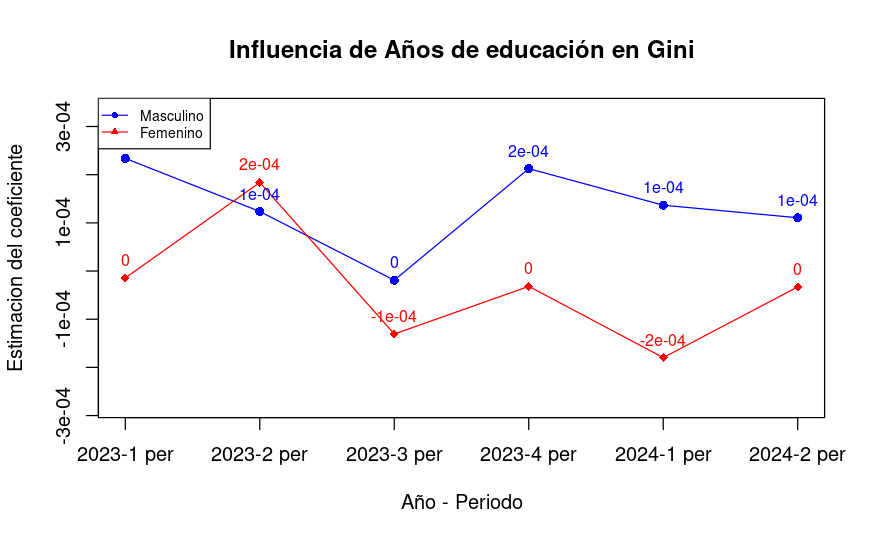

```r
graph_RIF(coefs_rif_edu_mas,coefs_rif_edu_fem)
```

Observando los valores de las estimaciones, vemos que las estimaciones no parecen seguir un comportamiento negativo y positivo, tienen órdenes de magnitud poco significativos, lo que indica que el efecto es moderado en términos absolutos, sin importar el signo no se ve una influencia en la reducción de la brecha salarial.

Probablemente necesite ser complementado con otras medidas, como políticas de acceso al mercado laboral y demás factores. Además, dado que el índice de Gini mide desigualdad de manera agregada, cambios en la educación pueden tardar en reflejarse de manera significativa en la distribución salarial.

### **Influencia de las variables en la Diferencia salarial | Descomposición Oaxaca-Blinder**

Para cuantificar la influencia de la educación, experiencia laboral (potencial) y horas trabajadas en la diferencia salarial, vamos a usar la descomposición de Oaxaca-Blinder usando como coeficientes de referencia el modelo propuesto por Jann (2008) que brinda la posibilidad de ampliar un análisis si fuese asi a mas de dos grupos, además porque suponemos que ambos géneros comparten la misma estructura salarial.

Para ello aplicamos el método de heckman a ambos géneros, pues encontramos que la variable $\lambda$ es significativa en ambos modelos, para tener resultados totalmente comparables así tener una consistencia metodológica simétrica. No mencionó la contribución a la brecha salarial de la variable debido a que su interpretabilidad no resulta directa, ya que no es una característica del individuo “promedio”, sino del proceso de selección en el mercado laboral.

```r
# Primero definimos la lista donde iteraremos cada data.frame
bases23_fem_hm <- list()
bases23_mas_hm <- list()
for(i in 1:4){
  aux <- f_restricciones(bases23[[i]], gender = "fem", asalariado = FALSE)
  aux <- mergear(aux, hogares23[[i]], bases23[[i]])
  bases23_fem_hm[[i]] <- Heckman_method(aux)

  aux <- f_restricciones(bases23[[i]], gender = "mas", asalariado = FALSE)
  aux <- mergear(aux, hogares23[[i]], bases23[[i]])
  bases23_mas_hm[[i]] <- Heckman_method(aux)
}
bases24_fem_hm <- list()
bases24_mas_hm <- list()
for(i in 1:2){
  aux <- f_restricciones(bases24[[i]], gender = "fem", asalariado = FALSE)
  aux <- mergear(aux, hogares24[[i]], bases24[[i]])
  bases24_fem_hm[[i]] <- Heckman_method(aux)

  aux <- f_restricciones(bases24[[i]], gender = "mas", asalariado = FALSE)
  aux <- mergear(aux, hogares24[[i]], bases24[[i]])
  bases24_mas_hm[[i]] <- Heckman_method(aux)
}
```

```r
fem_23 <- bases23_fem_hm[[1]] %>% filter(ingreso >0)
mas_23 <- bases23_mas_hm[[1]] %>% filter(ingreso >0)

fem_24 <- bases24_fem_hm[[2]] %>% filter(ingreso >0)
mas_24 <- bases24_mas_hm[[2]] %>% filter(ingreso >0)

fem_23$fem = 1; fem_24$fem = 1
mas_23$fem = 0; mas_24$fem = 0
data_combined23 <- rbind(fem_23, mas_23) ; data_combined24 <- rbind(fem_24, mas_24)
data_combined23$fem <- as.numeric(as.character(data_combined23$fem));  data_combined24$fem <- as.numeric(as.character(data_combined24$fem))
```

```r
oaxaca_result23 <- oaxaca(
  formula = log(ingreso) ~ anios_edu + exp_pot + exp_pot_2 + as.factor(PP04C) + log_horas + lambda | fem,
  data = data_combined23,
)
```

[output not shown]

```r
oaxaca_result24 <- oaxaca(
  formula = log(ingreso) ~ anios_edu + exp_pot + exp_pot_2 + as.factor(PP04C) + log_horas + lambda | fem,
  data = data_combined24,
)
```

[output not shown]

Vamos a usar la siguiente transformación para cuantificar en términos de porcentaje la diferencia salarial, dada $x = Media(log(ingresoA)) - Media(log(ingresoB))$

$$e^{x} - 1$$
Como tenemos una cantidad de datos similar correspondientes a los diferentes grupos (géneros), aprovechando propiedades del log junto con la media geométrica, encuentro esta transformación adecuada para obtener una cuantificación interpretativa.

### Brecha Salarial y Diferencias en Ingresos

#### 2023

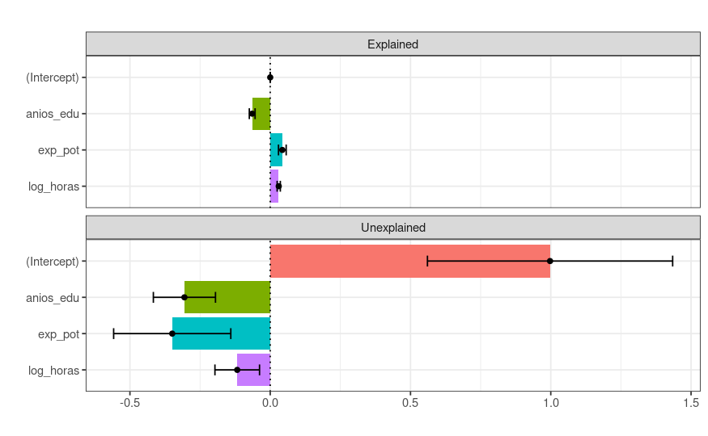

```r
# "(Intercept)","lambda","exp_pot_2"
aver <- c("(Intercept)","anios_edu","exp_pot","log_horas")
twoFold23 <- oaxaca_result23$twofold$overall[6,]

plot(oaxaca_result23, decomposition = "twofold", group.weight = -2, variables = aver)
```

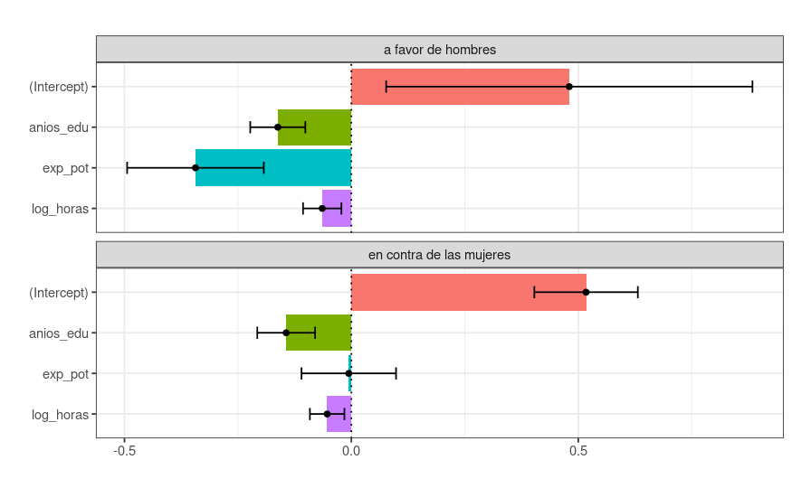

```r
plot(oaxaca_result23, decomposition = 'twofold', group.weight = -2, unexplained.split = TRUE, components = c("unexplained A","unexplained B"),
     component.labels = c("unexplained A" = "a favor de hombres", 'unexplained B' = "en contra de las mujeres"),
     variables = aver)
```

#### 2024

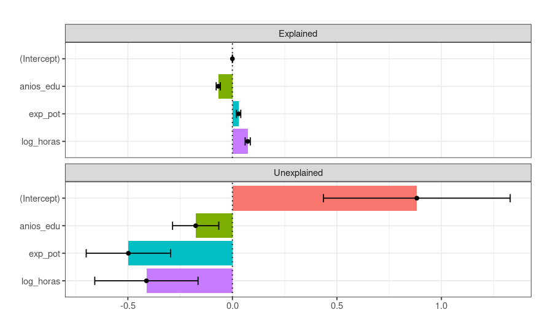

```r
twoFold24 <- oaxaca_result24$twofold$overall[6,]

plot(oaxaca_result24, decomposition = "twofold", group.weight = -2,variables = aver)
```

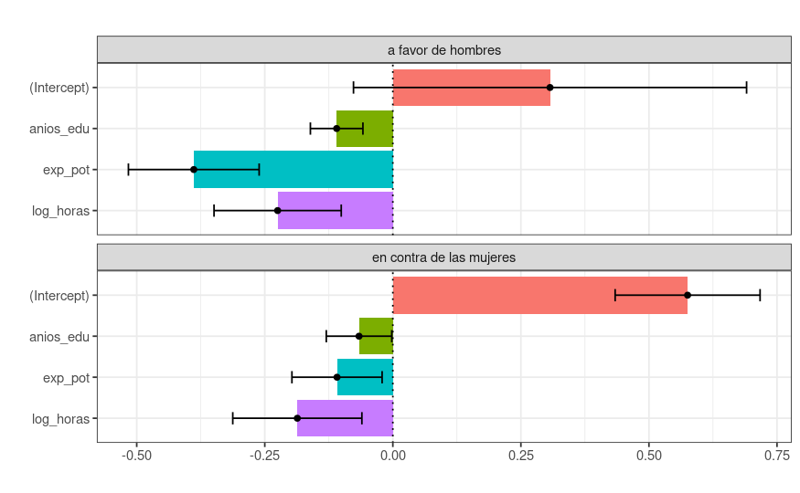

```r
plot(oaxaca_result24, decomposition = 'twofold', group.weight = -2, unexplained.split = TRUE, components = c("unexplained A","unexplained B"),
     component.labels = c("unexplained A" = "a favor de hombres", 'unexplained B' = "en contra de las mujeres"),
      variables = aver)
```

En 2023, la brecha salarial de género muestra que los hombres perciben, en promedio, un **48% más** de ingresos que las mujeres. Para 2024, esta diferencia aumenta en **1.3 puntos porcentuales**, lo que indica una **tendencia al ensanchamiento de la brecha salarial**.

La diferencia en los **interceptos** entre ambos años se mantiene cercana a **1**, con una varianza de aproximadamente **0.25**. Esto sugiere que **existe una diferencia estructural salarial significativa** entre hombres y mujeres, la cual **afecta más a la brecha que las propias características observables**. Sin embargo, dentro de la **parte no explicada de la descomposición Oaxaca-Blinder**, variables como **años educativos, experiencia potencial (exp_pot) y logaritmo de horas trabajadas (log_horas)** también juegan un rol importante.

#### Parte Explicada vs. No Explicada

En ambos años, la **parte explicativa** contribuye en menor medida a la brecha en comparación con la **parte no explicada**, lo que resalta la importancia de diferencias en la valoración del mercado más que en las características individuales de los trabajadores.

- **2023:** La parte explicada representa un **26.8%** de la brecha total.
- **2024:** La parte explicada aumenta a un **39.3%**, lo que indica que una mayor proporción de la brecha puede atribuirse a diferencias en características observables.

En ambos años, el coeficiente de la parte explicada tiene signo positivo, lo que implica que **las características observables favorecen al género masculino** en términos salariales. En 2023, esto representaba aproximadamente un **11% de ventaja** en el ingreso masculino frente al femenino, mientras que en 2024 este valor aumenta al **17%**, reflejando un **ensanchamiento de la brecha explicada**.

#### Análisis de Variables Clave en la Parte Explicada

#### Años Educativos (`anios_edu`) → -0.06

El coeficiente negativo indica que **las mujeres, en promedio, tienen más años educativos que los hombres**. Dado que existe una **relación positiva entre educación e ingresos**, esto debería reducir la brecha salarial. Sin embargo, esta diferencia no es suficiente para compensar otros factores que amplían la desigualdad.

En promedio, **los hombres tienen más años de experiencia potencial que las mujeres**. Esto puede explicarse por **interrupciones laborales más frecuentes en la carrera profesional de las mujeres**, debido a factores como licencias por maternidad o mayores responsabilidades en el hogar. Se observa un comportamiento similar para `exp_pot_2`, con el signo cambiado, lo que sugiere que **a medida que aumenta la experiencia, el crecimiento salarial se desacelera**, explicando parte de la brecha.

#### Logaritmo de Horas Trabajadas (`log_horas`) → 0.03 (2023) | 0.07 (2024)

En promedio, **los hombres reportan más horas laborales en su ocupación principal**. Esto contribuye a la parte explicativa de la brecha, ya que un **mayor número de horas trabajadas tiende a estar asociado con mayores ingresos**. En 2024, el coeficiente aumenta, lo que sugiere que la diferencia en horas trabajadas **explica una mayor proporción de la brecha salarial respecto a 2023**.

#### Parte No Explicada y Factores Subyacentes

En **2023 y 2024**, la **parte no explicada** representó el **73% y el 61%** de la brecha salarial, respectivamente. Esto significa que la mayor parte de la diferencia salarial **no puede atribuirse a diferencias en características observables** como educación, experiencia o ubicación, sino a **cómo el mercado valora y remunera a cada género**.

#### Posibles Causas de la Parte No Explicada

- **Diferencias en los retornos a las características observables**: El mercado puede otorgar un **mayor o menor retorno** a la educación, la experiencia o la ubicación según el género.
- **Factores estructurales y culturales**: Normas sociales o condiciones laborales que afectan de manera diferente a hombres y mujeres.
- **Discriminación salarial o segregación ocupacional**: Diferencias en oportunidades de ascenso, sectores de trabajo predominantemente masculinos o femeninos, o barreras implícitas en el acceso a mejores empleos.
- **Omisión de variables relevantes**: Factores no incluidos en el análisis, como habilidades específicas, redes de contacto o diferencias en la negociación salarial.

La disminución de la contribución de la parte no explicada entre 2023 y 2024 sugiere una posible reducción en la desigualdad estructural, aunque sigue siendo la principal fuente de la brecha salarial de género.

La reducción del coeficiente del intercepto en la parte no explicada entre 2023 y 2024 indica que la ventaja estructural que el mercado laboral otorgaba a los hombres ha disminuido. Es decir, la parte de la brecha salarial que no puede explicarse por diferencias en educación, experiencia u otras características observables ha cambiado en detrimento del grupo masculino. Sin embargo, dado que el intervalo de confianza incluye valores negativos, la estimación no es estadísticamente significativa. Esto sugiere que, aunque hay indicios de una reducción en la ventaja estructural de los hombres, no podemos afirmar con certeza que este cambio sea distinto de cero con un alto nivel de confianza.

Observamos una disminución en la penalización hacia los hombres en los años educativos. En 2023, la desventaja no explicada atribuida a los hombres fue de **-0.16**, reduciéndose a **-0.1** en 2024. Esto sugiere que, aunque persiste una diferencia en los retornos a la educación en contra de los hombres, su magnitud se ha reducido. En contraste, en el caso de las mujeres, la ventaja no explicada también se ha reducido. En 2023, el componente no explicado a favor de las mujeres era de **-0.14**, mientras que en 2024 disminuyó a **-0.06**. Esto indica que las mujeres estaban obteniendo un mayor retorno relativo por la educación en comparación con los hombres, pero esta ventaja se ha reducido en el último período.

```r
porce(twoFold23[['coef(explained)']] + twoFold23[['coef(unexplained)']]) # transformacion para el procentaje de la diferencia salarial 2023
```

```
[1] 0.4815122
```

```r
porce(twoFold24[['coef(explained)']] + twoFold24[['coef(unexplained)']]) # transformacion para el procentaje de la diferencia salarial 2024
```

```
[1] 0.4942331
```

```r
porce(twoFold23[['coef(explained)']]) # transformacion para el procentaje de la diferencia salarial 2023 parte explicada
```

```
[1] 0.1112046
```

```r
porce(twoFold24[['coef(explained)']]) # transformacion para el procentaje de la diferencia salarial 2024 parte explicada
```

```
[1] 0.1711807
```

```r
oaxaca_result23$twofold$variables[[6]]
```

```
                   group.weight coef(explained) se(explained) coef(unexplained) se(unexplained) coef(unexplained A) se(unexplained A) coef(unexplained B) se(unexplained B)
(Intercept)                  -2     0.000000000   0.000000000      9.974274e-01     0.222962032        4.802258e-01       0.205914670        0.5172016260       0.058191949
anios_edu                    -2    -0.064251022   0.005245701     -3.058015e-01     0.056485525       -1.621468e-01       0.030963912       -0.1436546924       0.032494945
exp_pot                      -2     0.043192606   0.006988100     -3.492912e-01     0.106517236       -3.435451e-01       0.076827540       -0.0057460418       0.053148020
exp_pot_2                    -2    -0.033024992   0.005439743      1.257188e-01     0.058733303        1.320408e-01       0.035115969       -0.0063220122       0.030889764
as.factor(PP04C)1            -2     0.006483138   0.002432087      3.979671e-02     0.032434362        2.127568e-02       0.030907453        0.0185210262       0.003242402
as.factor(PP04C)2            -2     0.012660962   0.002154132      6.692665e-03     0.016042759        5.168585e-03       0.015538111        0.0015240800       0.001785222
as.factor(PP04C)3            -2     0.009683039   0.002591248      5.376006e-03     0.010342866        3.855875e-03       0.009982134        0.0015201309       0.001417308
as.factor(PP04C)4            -2     0.004408640   0.002433049      5.605463e-04     0.006988882        8.646501e-04       0.006555506       -0.0003041038       0.001232812
as.factor(PP04C)5            -2     0.007658194   0.002193006     -1.401714e-03     0.006630176        4.557428e-04       0.006336206       -0.0018574564       0.000992111
as.factor(PP04C)6            -2     0.006610922   0.004199668      1.037716e-02     0.016698012        6.750690e-03       0.016099158        0.0036264664       0.002025500
as.factor(PP04C)7            -2    -0.003409759   0.004506989     -1.492852e-03     0.014927051       -1.069265e-05       0.014423347       -0.0014821590       0.001855039
as.factor(PP04C)8            -2    -0.010567406   0.005778393      6.495309e-04     0.012476780        9.690523e-04       0.011879895       -0.0003195213       0.001726806
as.factor(PP04C)9            -2     0.003409777   0.005934702      6.027628e-04     0.016307352        1.310665e-03       0.016070286       -0.0007079021       0.001851710
as.factor(PP04C)10           -2     0.010822741   0.005083389     -1.481010e-03     0.010897913        1.066869e-04       0.010546158       -0.0015876970       0.001382897
as.factor(PP04C)11           -2     0.011429063   0.004891709     -2.436372e-05     0.009659559        2.913756e-04       0.009269320       -0.0003157393       0.001100180
as.factor(PP04C)12           -2     0.018108763   0.005637070      6.781592e-03     0.012166867        3.622090e-03       0.011499841        0.0031595025       0.001725480
as.factor(PP04C)99           -2     0.033525488   0.004831518      9.160995e-03     0.024982739        6.784899e-03       0.024069570        0.0023760963       0.002359741
log_horas                    -2     0.030328603   0.002878781     -1.175842e-01     0.040535213       -6.422205e-02       0.021568643       -0.0533621406       0.019413116
lambda                       -2     0.018375936   0.010071432     -1.384488e-01     0.013375497       -9.379790e-02       0.017146729       -0.0446508642       0.010260331
```

```r
oaxaca_result24$twofold$variables[[6]]
```

```
                   group.weight coef(explained) se(explained) coef(unexplained) se(unexplained) coef(unexplained A) se(unexplained A) coef(unexplained B) se(unexplained B)
(Intercept)                  -2     0.000000000   0.000000000       0.882366229     0.227822188         0.306895312       0.195770861        5.754709e-01       0.072177323
anios_edu                    -2    -0.067669188   0.005041290      -0.175681316     0.056405500        -0.109681023       0.026161905       -6.600029e-02       0.032620896
exp_pot                      -2     0.029801123   0.005233217      -0.497577429     0.102966950        -0.388611095       0.065108733       -1.089663e-01       0.044917372
exp_pot_2                    -2    -0.025681952   0.004725466       0.232012278     0.058373181         0.172485040       0.034026867        5.952724e-02       0.027481641
as.factor(PP04C)1            -2     0.006320578   0.001975319       0.088586519     0.036353063         0.072850871       0.035228121        1.573565e-02       0.003284464
as.factor(PP04C)2            -2     0.008808148   0.001947501       0.032625144     0.016563721         0.029838673       0.016126308        2.786471e-03       0.002239476
as.factor(PP04C)3            -2     0.009864715   0.002366068       0.022758948     0.009783290         0.019206395       0.009160790        3.552552e-03       0.001471956
as.factor(PP04C)4            -2     0.005452166   0.001826831       0.009796842     0.006353291         0.010089880       0.006047286       -2.930388e-04       0.001127397
as.factor(PP04C)5            -2     0.005255795   0.001925027       0.008501869     0.006117291         0.008879735       0.005800654       -3.778658e-04       0.001037143
as.factor(PP04C)6            -2     0.011092910   0.003771582       0.022612661     0.017282822         0.024982378       0.016650206       -2.369717e-03       0.002096213
as.factor(PP04C)7            -2    -0.001242735   0.004894860       0.036357176     0.016852132         0.030694985       0.015954166        5.662191e-03       0.002329897
as.factor(PP04C)8            -2    -0.025621517   0.005057991       0.021486848     0.011935574         0.018862343       0.011261423        2.624505e-03       0.002164839
as.factor(PP04C)9            -2     0.004858624   0.005528134       0.029063940     0.017536312         0.027864357       0.016884623        1.199583e-03       0.002121935
as.factor(PP04C)10           -2     0.005920937   0.004440529       0.020516839     0.011284911         0.018730228       0.010638019        1.786611e-03       0.001673654
as.factor(PP04C)11           -2     0.009501224   0.004724352       0.016708153     0.009184792         0.015616595       0.008976745        1.091559e-03       0.001189109
as.factor(PP04C)12           -2     0.022291232   0.005576148       0.017133058     0.011493086         0.017120795       0.011111421        1.226228e-05       0.001735752
as.factor(PP04C)99           -2     0.030461442   0.005470124       0.045000162     0.022352376         0.039966561       0.021442276        5.033602e-03       0.002639660
log_horas                    -2     0.073315108   0.006270389      -0.411379021     0.126048524        -0.224914033       0.063354659       -1.864650e-01       0.064307977
lambda                       -2     0.055283784   0.005118439      -0.157288199     0.014139966        -0.090877997       0.010629667       -6.641020e-02       0.006099675
```

```r
twoFold23[["coef(explained)"]] / (twoFold23[['coef(explained)']] + twoFold23[['coef(unexplained)']]) # porcentaje parte explicada 2023, del total de la diferencia salarial
```

```
[1] 0.2682639
```

```r
twoFold24[["coef(explained)"]] / (twoFold24[['coef(explained)']] + twoFold24[['coef(unexplained)']]) # porcentaje parte explicada 2024, del total de la diferencia salarial
```

```
[1] 0.3934443
```

```r
twoFold23[["coef(unexplained)"]] / (twoFold23[['coef(explained)']] + twoFold23[['coef(unexplained)']]) # porcentaje parte no explicada 2023, del total de la diferencia salarial
```

```
[1] 0.7317361
```

```r
twoFold24[["coef(unexplained)"]] / (twoFold24[['coef(explained)']] + twoFold24[['coef(unexplained)']]) # porcentaje parte no explicada 2024, del total de la diferencia salarial
```

```
[1] 0.6065557
```